# Measuring confidence in a phylogeny

## 4. Identify bipartitions with low internode certainty values

To examine internode certainty values among bipartitions in our putative species tree, we will first execute a script that replaces bootstrap values with internode support values and forgo examination of internode certainty all values. We will then view the tree in FigTree or similar software. Note, if you’d like to use a webservice like [phylo.io](https://phylo.io/), you can `cat` the tree file and copy and paste the resulting text into the `Tree data` box on the [phylo.io](https://phylo.io/) website.

Steps:

1. To report internode certainty values as support values, we will use the file `FILES_scripts_and_matrices/report_ic_as_internode_support.py`. To understand how to use the script, execute the following command:

```bash
python FILES_scripts_and_matrices/report_ic_as_internode_support.py -h
```

2. Based on the help message printed from the previous command, execute the script on the following tree `RAxML_IC_Score_BranchLabels.Asp_Pen_phylo.ic` to report internode certainty values as support values.

Solution

```bash
python FILES_scripts_and_matrices/report_ic_as_internode_support.py -t RAxML_IC_Score_BranchLabels.Asp_Pen_phylo.ic
```

3. Open up the resulting file, `RAxML_IC_Score_BranchLabels.Asp_Pen_phylo.ic.ic.tree`, using FigTree or your preferred tree viewer.
4. In [Steenwyk et al. (2019) *mBio*](https://jlsteenwyk.com/publication_pdfs/2019_Steenwyk_et_al_mBio.pdf), we further scrutinized bipartitions with internode certainty values <0.1. Our reasoning is that internodes with this value or lower have ~5 evaluation trees that support the reference topology and ~2 or more phylogenies that support an alternative topology - we consider this substantial incongruence.
5. Identify the internode with an internode certainty below 0.1 and specify the value and which internode that is in the phylogeny below. Note, you will have midpoint root the phylogeny first, or place the root at ancestor of *U. reesii* and *C. posadasii*.

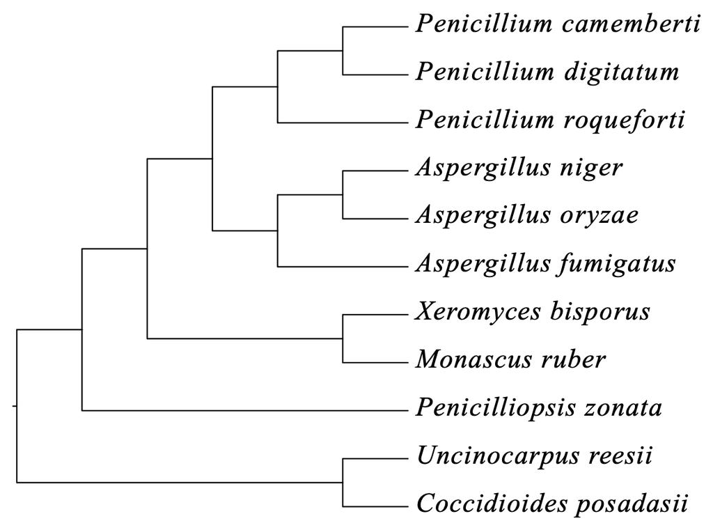

Solution:

```bash
The branch at the ancestor of M. ruber and P. camemberti has a low IC value.
```

## 5. Determine gene support frequency and concordance factors for the reference and alternative topology at the contentious internode

- To determine gene support frequency, we will use RAxML. Note, you have previously calculate gene support frequencies with PhyKIT when you used the `pk_ptt` function.
- To determine concordance factors, we will use IQ-Tree.

Steps:

1. Examine the verboseSplits output from RAxML, which is file `RAxML_verboseSplits.Asp_Pen_phylo.ic`
2. The bipartition for the contentious internode of question is second to last instance of the string ‘partition:’, which appears as the following: partition:

---** ***** * xx/yy/zz  
--*--* **** * xx/yy/zz  
--*** ----- - xx/yy/zz

where `xx/yy/zz` represents the following:

- xx: the number of genes that support a given bipartition,
- yy: the gene support frequency of the given bipartition, and • zz: the internode certainty value for the given internode.

We will focus on the first two topologies which consider whether the genus *Penicilliopsis* is more closely related to outgroup taxa or if *Xeromyces* and *Monascus* is. In other words, which genus/genera *Penicilliopsis* or *Xeromyces* and *Monascus* is sister to all other members of this fungal family?

What is the number of genes and gene support frequency that support the two topologies?

Solution:

```bash
First topology:
375/29.137529

Second topology:
340/26.418026
```

3. Now, calculate gene and site concordance factors in the following single command.

```bash
iqtree2 -t Asp_Pen_phylo.subset.new --gcf 1287.trees --scf 100 -p FILES_AA_fastas_subset/ --prefix gcf1297_scf100_ref
```

where:

- -t specifies the putative species tree,
- --gcf represents the 1287.trees observed single gene trees,
- --scf 100 represents that 100 quartets will be randomly for each internal branch for computing site concordance factors,
- -p specifies the directory that has the single gene fasta files, and
- --prefix specifies the prefix of the output files.
4. There are four resulting files:
- a log file,
- a cf.tree file with gene concordance factors,
- a cf.branch file with internal branch identifiers, and
- a cf.stat file with tab-separated values of gene and site concordance as well as gene and site discordance factors for each internode.

For now, we will focus on gene and site concordance factors.

5. Reexamine the contentious bipartition in the `gcf1297_scf100_ref.cf.tree` file, which can be viewed in FigTree or similar software. What is the gene concordance and site concordance factor for the contentious bipartition?

Solution:

```bash
0.155/32.1
```

6. Conduct the same analysis using the alternative topology as an input by executing the following command:

```bash
iqtree2 -t Asp_Pen_phylo.subset.alt.new --gcf 1287.trees --scf 100 -p FILES_AA_fastas_subset/ --prefix gcf1297_scf100_alt
```

7. Examine the contentious bipartition where *Penicilliopsis zonata* splits from *Aspergillus* and *Penicillium* in file `gcf1297_scf100_alt.cf.tree`. What is the gene concordance factor and site concordance factor for this bipartition?

Solution:

```bash
0/36.2
```

## 6. Calculate gene-wise and site-wise phylogenetic signal

To determine gene-wise and site-wise phylogenetic signal, we will follow protocol first described in [Shen et al. (2017), Nature Ecology and Evolution](https://www.nature.com/articles/s41559-017-0126) and calculate gene-wise and site-wise log-likelihood scores. We will use IQ-Tree to facilitate the analysis.

Steps:

1. Calculating gene-wise and site-wise log-likelihood scores takes too much time – **so do not execute the following commands**. The following commands are provided because I wanted you to have access and an understanding of how the results files you will be using were created.

```bash
# Command 1
iqtree2 -s FILES_scripts_and_matrices/concat.fa -seed 78913467814 -st AA -pre likelihood_ref -spp FILES_scripts_and_matrices/partition.file -te Asp_Pen_phylo.subset.new -wpl -wsl

# Command 2
iqtree2 -s concatenation.fasta -seed 13469781343 -st AA -pre likelihood_alt -spp partition.file -te FILES_GLS_files/concatenation.alt.topology -wpl -wsl
```

2. In the previous two commands, what do the following specify? Hint, it will be useful to use their documentation – see http://www.iqtree.org/doc/Command-Reference.
- -spp
- -te
- -wpl
- -wsl
3. Create summary files with gene-wise and site-wise log likelihood scores using a custom script provided for you. To do so, first change directories into FILES_gene_and_site_lh_values with the following command:

```bash
cd FILES_gene_and_site_lh_values
```

Next examine how to use the script that will create summary files for you using the following command:

```bash
bash ../FILES_scripts_and_matrices/create_GLS_summary.sh -h
```

Based on the help message, create gene-wise and site-wise log likelihood score summary files using the following command:

```bash
bash ../FILES_scripts_and_matrices/create_GLS_summary.sh ../FILES_scripts_and_matrices/partition.file likelihood_ref.partlh likelihood_alt.partlh likelihood_ref.sitelh likelihood_alt.sitelh
```

4. We will now examine the contents of gene-wise_logli_scores.txt and site-wise_logli_scores.txt. To do so, we will plot the results from each file in RStudio using ggplot2. First, establish an RStudio server connection in a new window and load ggplot2 using the following command:

```r
library(ggplot2)
```

If you are not in the working directory with your results files, use `setwd('path')` to change to the appropriate directory. Make sure you are in the appropriate directory with the `getwd()` command.

5. Next, read in the data tables using the following command:

```r
gene <- read.table("gene-wise_logli_scores.txt", sep = "\t")
```

```r
ggplot(gene, aes(V1, V4, color = V5)) + geom_bar(stat = "identity") + ggtitle("GLS (gene-wise)") +
    xlab("Genes") + ylab("deltaGLS") + theme_classic() + theme(axis.text.x = element_blank(),
    axis.ticks.x = element_blank()) + scale_color_manual(values = c("#56B4E9", "#999999",
    "#E69F00"))
```

7. There is one gene with overwhelming phylogenetic signal. To determine what gene this is, sort the data stored as gene according to the column of ΔGLS values using the following command and examine the fourth column, which is ΔGLS:

```r
head(gene[order(-gene$V4), ])
```

8. What gene has a high ΔGLS in favor of the reference topology?

Solution

```bash
EOG091N0K4M has a ΔGLS of 113.180
```

9. To determine if removing this gene will switch the topology at the given internode, calculate the sum of log likelihood values after removing the gene-wise log likelihood score for this gene. To do so, execute the following command:

```r
sum(gene[(gene$V4 != 113.18), ]$V4)
```

where

- `sum()` will calculate the sum of a set of numbers and
- `gene[(gene$V4!=113.180),]$V4` will print the set of numbers excluding the highly opinionated gene.
10. Does the topology change if you remove this gene?

Solution

```bash
sum w/ 400.72
sum w/out 287.54

No, because the sum of phylogenetic signal is still (+).
```

11. Repeat v and vi for site-wise_logli_scores.txt by executing the following commands:

```r
# read in site-wise log likelihood scores file
site <- read.table("site-wise_logli_scores.txt", sep = "\t")
# create plot
ggplot(site, aes(V1, V4, color = V5)) + geom_bar(stat = "identity") + ggtitle("SLS (site-wise)") +
    xlab("Sites") + ylab("deltaSLS") + theme_classic() + theme(axis.text.x = element_blank(),
    axis.ticks.x = element_blank()) + scale_color_manual(values = c("#56B4E9", "#999999",
    "#E69F00"))
```

Note, this plot may take 5-10 minutes to generate. If you don’t want to wait, see `FILES_results/FILES_gene-wise_site-wise_log_likelihood/site_wise.png` for a premade PNG file of the same plot that would be generated.

12. Is there one site with overwhelming signal?

Solution

```r
No
```

## 7. Bonus

1. Using only starting data of gene trees, use internode certainty (and/or related measures) to rank the following datasets (which are found in FILES_bonus_datasets) from most consistent among single-gene trees to least. The four datasets are:
- Eutheria, a lineage of mammals,
- budding yeasts,
- filamentous fungi, and
- mammals

Each dataset has both SC-OGs and SNAP-OGs. For this bonus question, use both SC-OGs and SNAP-OGs.

Light hints for overall workflow

```bash
1. You will have to infer a summary tree (aka, species tree estimate) first. How do you infer a species tree from a collection of single gene trees?

2. Use the PhyKIT function `bipartition_support_stats` to get summary statistics support statistics in a phylogeny. Support statistics have to be reported in the position bootstrap statistics are reported.
```

Detailed hints for overall workflow

```bash
1. To do so, first infer a summary tree using ASTRAL and then use the input trees as evaluation trees to calculate internode certainty and related measures in RAxML.
astral.jar -i all_trees.tre -o output_tree

2. Calculate internode certainty
raxmlHPC -f i -t output_tree -z all_trees.tre -m GTRCAT -n output_tree.ic -C

3. Use `report_ic_as_internode_support.py` to reformat IC values as bootstrap values

4. Use the PhyKIT function `bipartition_support_stats` to get summary statistics of internode certainty values across the tree
# https://jlsteenwyk.com/PhyKIT/usage/index.html#bipartition-support-statistics
phykit bipartition_support_stats input.tree

5. Keep track of your summary statistic of choice across each dataset and rank the datasets by which has the most to least certainty.
```

Solution

```bash
Gotcha!!!!

No solution will be provided here. Grab a TA, discuss with them and show them your results.
```

2. For each dataset, calculate summary statistics of internode certainty (or related measures) between SC-OGs and SNAP-OGs. How is certainity similar or different between SC-OGs and SNAP-OGs?

Solution

```bash
Gotcha again!!!!

No solution will be provided here. Grab a TA, discuss with them and show them your results.
```